# Exploring Alcohol Use and Annual family income influential factors in NHANES 2017-18.

## Preliminaries

```r
# I think every project will need at least these packages
library(here)
library(janitor)
library(knitr)
library(magrittr)
library(naniar)
library(gtsummary)
library(broom)
library(rsample)
library(yardstick)
library(rms)
library(MASS)
library(stats)
library(magrittr)
library(gmodels)
library(nnet)
library(mosaic)
library(countreg)
library(nhanesA)
library(pscl)
library(Hmisc)
library(patchwork)
library(simputation)
library(conflicted)
library(ROCR)
library(tidyverse)
library(base)
theme_set(theme_bw())
conflict_prefer("filter","dplyr")
conflict_prefer("select","dplyr")
conflict_prefer("zeroinfl","pscl")
conflict_prefer("sum", "base")
conflict_prefer("rsq", "yardstick")
```

# 1 Background

The purpose of this project is to study and discuss what factors influence a person’s alcohol consumption and annual household income. The amount of daily drinking is caused by many factors. We hope to find the factors that affect people’s drinking to find a way to help some people who need to quit drinking. Similarly, there are many factors that affect household income, and we want to build a model to predict the annual household income level. As covid-19 has changed the way people live, we will choose to use the 2017-2018 data from NHANES.

# 2 Research Questions

1. What’s the relationship between number of average daily drinking and personal social and health conditions?
2. How well can we predict annual family income base on the characters of family members?

# 3 My Data

The source of my data is NHANES 2017-2018. The National Health and Nutrition Examination Survey (NHANES) is a program of studies designed to assess the health and nutritional status of adults and children in the United States. We selected variables that we thought were related to alcohol consumption and household income.

## 3.1 Data Ingest

Read data from Nhanes package. And we’ll rename these variables.

```r
database_raw<-merge(nhanes('ALQ_J'),nhanes('DEMO_J'))%>%
  merge(nhanes('BPX_J'))%>%
  merge(nhanes('HDL_J'))%>%
  merge(nhanes('TRIGLY_J'))%>%
  merge(nhanes('SMQ_J'))%>%
  merge(nhanes('CBQ_J'))%>%
  merge(nhanes('PAQ_J'))%>%
  merge(nhanes('WHQ_J'))%>%
  select(SEQN,RIDSTATR,
         ALQ130,ALQ121,RIDAGEYR,RIDRETH3,BPXSY1,LBDHDD,LBDLDL,
         INDFMIN2,SMQ040,DMDEDUC2,PAQ610,CBD091,WHD140)
```

```
Processing SAS dataset ALQ_J     ..
Processing SAS dataset DEMO_J    ..
Processing SAS dataset BPX_J     ..
Processing SAS dataset HDL_J     ..
Processing SAS dataset TRIGLY_J      ..
Processing SAS dataset SMQ_J     ..
Processing SAS dataset CBQ_J     ..
Processing SAS dataset PAQ_J     ..
Processing SAS dataset WHQ_J     ..
```

```r
names(database_raw)=c("SEQN","Interview",
                      "Daily_drink","Drink_freq","Age","Race","SBP","HDL","LDL",
                      "Income","Smoking","Education","Vigorous_work","Nonfood_bill","Greatest_weight")
```

## 3.2 Tidying, Data Cleaning and Data Management

Here we want to clean the raw data. The first step is filter samples with complete outcomes: `Daily_drink` and `Income`. Then we want to remove samples who have missing in `Greatest_weight`, `Income`, `Nonfood_bill` and `Education` because the missing rate of these variables is less than 5%. Removing them will not make a great difference.

`Race` also remove level of 7, which indicates other races. Because in analysis of question 1, we want to find the relationship between culture and drinking, “other races” can give poor information about it.

```r
database_raw$Daily_drink<-ifelse(database_raw$Drink_freq==0,0,database_raw$Daily_drink)
## Creating a counting outcome for question 1

data1_raw<-database_raw%>%
  filter(Interview==2)%>%
  filter(is.na(database_raw$Daily_drink)==0)%>%
  filter(Daily_drink!=777&Daily_drink!=999)%>% ## drop missing in our outcome
  filter(Income!=77&Income!=99&Income!=12&Income!=13)%>%
  filter(Education!=9&Education!=7&
           Nonfood_bill!=777777&
           Nonfood_bill !=999999&
           Drink_freq !=77&Drink_freq!=99&
           Greatest_weight!=7777&Greatest_weight!=9999&
           Race!=7) ## which indicates other races
```

```r
miss_var_summary(database_raw)
```

```
# A tibble: 15 x 3
   variable        n_miss pct_miss
   <chr>            <int>    <dbl>
 1 Vigorous_work     2014    75.9
 2 Smoking           1563    58.9
 3 Daily_drink        441    16.6
 4 Drink_freq         440    16.6
 5 SBP                319    12.0
 6 LDL                184     6.94
 7 HDL                153     5.77
 8 Nonfood_bill       117     4.41
 9 Income             116     4.37
10 Education          111     4.19
11 SEQN                 0     0
12 Interview            0     0
13 Age                  0     0
14 Race                 0     0
15 Greatest_weight      0     0
```

After removing missing samples, there are still five variables that isn’t complete. Then we’d use imputation

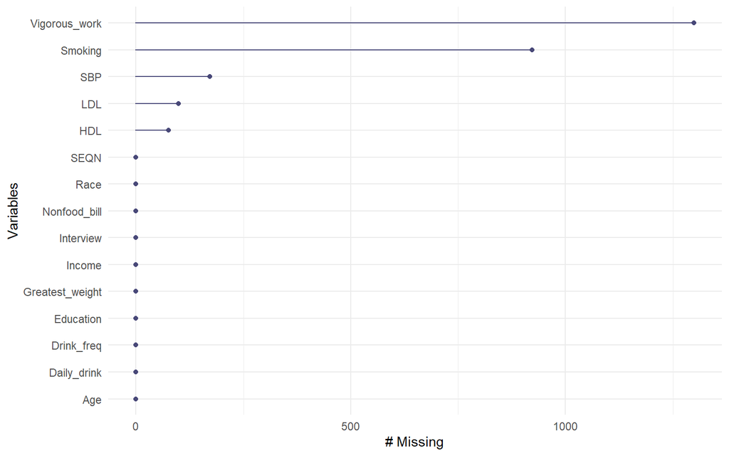

```r
gg_miss_var(data1_raw)
```

```r
miss_var_summary(data1_raw)
```

```
# A tibble: 15 x 3
   variable        n_miss pct_miss
   <chr>            <int>    <dbl>
 1 Vigorous_work     1299    74.9
 2 Smoking            922    53.2
 3 SBP                172     9.92
 4 LDL                 99     5.71
 5 HDL                 76     4.38
 6 SEQN                 0     0
 7 Interview            0     0
 8 Daily_drink          0     0
 9 Drink_freq           0     0
10 Age                  0     0
11 Race                 0     0
12 Income               0     0
13 Education            0     0
14 Nonfood_bill         0     0
15 Greatest_weight      0     0
```

```r
miss_case_table(data1_raw)
```

```
# A tibble: 6 x 3
  n_miss_in_case n_cases pct_cases
           <int>   <int>     <dbl>
1              0     201    11.6
2              1     689    39.7
3              2     696    40.1
4              3     110     6.34
5              4      33     1.90
6              5       5     0.288
```

```r
dim(data1_raw)
```

```
[1] 1734   15
```

After removing missing samples, we still have about 1700 samples left. We will use this data set in analysis of question 1&2.

## 3.3 Imputation

We chose the single imputations for five variables for it is simplicity in using and translating, and we hpythosized the following relationships among the missing varables and the other related categorical or numerical variables. The predictive mean matching method and robust linear regression method are used during this process.

```r
set.seed(432)
data1_imp<-data1_raw%>%
  impute_pmm(HDL~Age+Race+Income)%>%
  impute_rlm(LDL~Income+Education)%>%
  impute_rlm(SBP~Age+Education)%>%
  impute_pmm(Vigorous_work~Age+Race)%>%
  impute_pmm(Smoking~Age+Race)
```

## 3.4 Rename levels of categorical variables

Now we want to rename levels of categorial variables to make it easier to understand.

```r
data1_imp<-data1_imp%>%
  mutate(Race=Race%>%as.factor()%>%
           fct_recode("Mexican_American"="1",
                      "Other_Hispanic"="2",
                      "Non-Hispanic_White"="3",
                      "Non-Hispanic_Black"="4",
                      "Non-Hispanic_Asian"="6"
                      ),
         Smoking=Smoking%>%as.factor()%>%
           fct_recode("Smoke_Every_day"="1",
                      "Some_Days"="2",
                      "Never_Smoke"="3"),
         Education=Education%>%as.factor()%>%as.numeric(),

         Annual_family_income = case_when(
           Income<=5~"1_Low_income_level",
           Income>5&Income<=9~"2_Middle_income_level",
           Income>9~"3_High_income_level"),

         AFI_factor=Annual_family_income%>%as.factor(),
         AFI_factor = factor(AFI_factor, ordered = TRUE),

  )%>%
  as_tibble()
```

## 3.5 Tidied Tibble

```r
data1_imp
```

```
# A tibble: 1,734 x 17
   SEQN       Interview  Daily_drink Drink_freq Age   Race  SBP   HDL   LDL
   <labelled> <labelled>       <dbl> <labelled> <lab> <fct> <lab> <lab> <labell>
 1 93711      2                    1 5          56    Non-~ 108   72    156.0000
 2 93717      2                   15 1          22    Non-~ 116   53    140.0000
 3 93718      2                    0 0          45    Non-~ 128   63     80.0000
 4 93721      2                    1 5          60    Mexi~ 132   45     61.0000
 5 93722      2                    1 7          60    Non-~ 116   78     95.0000
 6 93731      2                    0 0          20    Mexi~ 114   40     97.0000
 7 93732      2                    1 4          72    Non-~ 132   53    107.7617
 8 93738      2                    2 7          26    Othe~ 120   41     89.0000
 9 93740      2                    0 0          72    Non-~ 178   54    106.8064
10 93742      2                    1 9          72    Non-~ 166   48     91.0000
# ... with 1,724 more rows, and 8 more variables: Income <labelled>,
#   Smoking <fct>, Education <dbl>, Vigorous_work <labelled>,
#   Nonfood_bill <labelled>, Greatest_weight <labelled>,
#   Annual_family_income <chr>, AFI_factor <ord>
```

```r
saveRDS(data1_imp, file="Nhanes17-18.Rds")
```

# 4 Code Book and Clean Data Summary

```r
data1_imp %>%
    select(Daily_drink, Age, Race, SBP, HDL, LDL, AFI_factor,
           Income, Smoking,Vigorous_work,Education, Nonfood_bill, Greatest_weight) %>%
    tbl_summary(.,label = list(
            Daily_drink = "Daily_drink: Avg # alcohol drinks/day(in last 12 months)",
            Age = "Age: Age in years at screening ",
            RIDRETH1 = "Race/Hispanic origin",
            SBP = "SBP: Systolic Blood Pres",
            HDL = "HDL: HDL-Cholesterol (mg/dL)",
            LDL = "LDL: LDL-cholesterol (mg/dL)",
            Smoking = "Smoking: Smoking status",
            Income = "Annual famiy income: income as discrete numbers representing the level of the income; the bigger the number the more the family earns",
            AFI_factor = "AFI_factor: Annual family income regrouped as Low, Middle(Medium), and High",
            Vigorous_work = "Vigorous_work: Number of days vigorous work",
            Education = "Education: Education level ",
            Nonfood_bill = "Nonfood_bill: Money spent on nonfood items",
            Greatest_weight = "Greatest_weight: Self-reported greatest weight (pounds)"),
            stat = list( all_continuous() ~
                "{median} [{min} to {max}]"))
```

| **Characteristic** | **N = 1,734**<sup>1</sup> |
| --- | --- |
| Daily_drink: Avg # alcohol drinks/day(in last 12 months) | 1.00 [0.00 to 15.00] |
| Age: Age in years at screening | 53 [20 to 80] |
| Race |  |
| Mexican_American | 250 (14%) |
| Other_Hispanic | 160 (9.2%) |
| Non-Hispanic_White | 693 (40%) |
| Non-Hispanic_Black | 430 (25%) |
| Non-Hispanic_Asian | 201 (12%) |
| SBP: Systolic Blood Pres | 124 [86 to 224] |
| HDL: HDL-Cholesterol (mg/dL) | 51 [22 to 151] |
| LDL: LDL-cholesterol (mg/dL) | 107 [18 to 357] |
| AFI_factor: Annual family income regrouped as Low, Middle(Medium), and High |  |
| 1_Low_income_level | 482 (28%) |
| 2_Middle_income_level | 639 (37%) |
| 3_High_income_level | 613 (35%) |
| Annual famiy income: income as discrete numbers representing the level of the income; the bigger the number the more the family earns | 7 [1 to 15] |
| Smoking: Smoking status |  |
| Smoke_Every_day | 264 (15%) |
| Some_Days | 872 (50%) |
| Never_Smoke | 598 (34%) |
| Vigorous_work: Number of days vigorous work |  |
| 1 | 57 (3.3%) |
| 2 | 57 (3.3%) |
| 3 | 376 (22%) |
| 4 | 939 (54%) |
| 5 | 202 (12%) |
| 6 | 52 (3.0%) |
| 7 | 51 (2.9%) |
| Education: Education level |  |
| 1 | 107 (6.2%) |
| 2 | 211 (12%) |
| 3 | 434 (25%) |
| 4 | 573 (33%) |
| 5 | 409 (24%) |
| Nonfood_bill: Money spent on nonfood items | 0 [0 to 600] |
| Greatest_weight: Self-reported greatest weight (pounds) | 194 [98 to 630] |

<sup>1</sup> Median [Range]; n (%)

```r
data1_imp %>% describe(.) %>% Hmisc::html()
```

.  
17 Variables 1734 Observations

SEQN: Respondent sequence number

| n | missing | distinct | Info | Mean | Gmd | .05 | .10 | .25 | .50 | .75 | .90 | .95 |
| --- | --- | --- | --- | --- | --- | --- | --- | --- | --- | --- | --- | --- |
| 1734 | 0 | 1734 | 1 | 98319 | 3142 | 94079 | 94526 | 95926 | 98335 | 100648 | 102063 | 102532 |

lowest : 93711 93717 93718 93721 93722 , highest: 102934 102935 102947 102952 102956

Interview: Interview/Examination status

| n | missing | distinct | Info | Mean | Gmd |
| --- | --- | --- | --- | --- | --- |
| 1734 | 0 | 1 | 0 | 2 | 0 |

```
 Value         2
 Frequency  1734
 Proportion    1
```

Daily_drink

| n | missing | distinct | Info | Mean | Gmd | .05 | .10 | .25 | .50 | .75 | .90 | .95 |
| --- | --- | --- | --- | --- | --- | --- | --- | --- | --- | --- | --- | --- |
| 1734 | 0 | 14 | 0.949 | 1.894 | 1.972 | 0 | 0 | 1 | 1 | 2 | 4 | 6 |

lowest : 0 1 2 3 4 , highest: 10 11 12 13 15

```
 Value          0     1     2     3     4     5     6     7     8    10    11    12
 Frequency    408   489   420   173    92    55    45     6    18    10     1     9
 Proportion 0.235 0.282 0.242 0.100 0.053 0.032 0.026 0.003 0.010 0.006 0.001 0.005

 Value         13    15
 Frequency      1     7
 Proportion 0.001 0.004
```

Drink_freq: Past 12 mo how often have alcohol drink

| n | missing | distinct | Info | Mean | Gmd | .05 | .10 | .25 | .50 | .75 | .90 | .95 |
| --- | --- | --- | --- | --- | --- | --- | --- | --- | --- | --- | --- | --- |
| 1734 | 0 | 11 | 0.981 | 4.796 | 4.036 | 0 | 0 | 1 | 5 | 8 | 10 | 10 |

lowest : 0 1 2 3 4 , highest: 6 7 8 9 10

```
 Value          0     1     2     3     4     5     6     7     8     9    10
 Frequency    408    65    68   103   133   117   225   137   113   173   192
 Proportion 0.235 0.037 0.039 0.059 0.077 0.067 0.130 0.079 0.065 0.100 0.111
```

Age: Age in years at screening

| n | missing | distinct | Info | Mean | Gmd | .05 | .10 | .25 | .50 | .75 | .90 | .95 |
| --- | --- | --- | --- | --- | --- | --- | --- | --- | --- | --- | --- | --- |
| 1734 | 0 | 61 | 0.999 | 51.25 | 20.1 | 23 | 26 | 36 | 53 | 64 | 75 | 80 |

lowest : 20 21 22 23 24 , highest: 76 77 78 79 80

Race

| n | missing | distinct |
| --- | --- | --- |
| 1734 | 0 | 5 |

| lowest : | Mexican_American | Other_Hispanic | Non-Hispanic_White | Non-Hispanic_Black | Non-Hispanic_Asian |
| --- | --- | --- | --- | --- | --- |
| highest: | Mexican_American | Other_Hispanic | Non-Hispanic_White | Non-Hispanic_Black | Non-Hispanic_Asian |

```
 Value        Mexican_American     Other_Hispanic Non-Hispanic_White
 Frequency                 250                160                693
 Proportion              0.144              0.092              0.400

 Value      Non-Hispanic_Black Non-Hispanic_Asian
 Frequency                 430                201
 Proportion              0.248              0.116
```

SBP: Systolic: Blood pres (1st rdg) mm Hg

| n | missing | distinct | Info | Mean | Gmd | .05 | .10 | .25 | .50 | .75 | .90 | .95 |
| --- | --- | --- | --- | --- | --- | --- | --- | --- | --- | --- | --- | --- |
| 1734 | 0 | 183 | 0.999 | 125.7 | 20.49 | 100 | 104 | 112 | 124 | 136 | 150 | 160 |

lowest : 86 88 90 92 94 , highest: 196 200 204 210 224

HDL: Direct HDL-Cholesterol (mg/dL)

| n | missing | distinct | Info | Mean | Gmd | .05 | .10 | .25 | .50 | .75 | .90 | .95 |
| --- | --- | --- | --- | --- | --- | --- | --- | --- | --- | --- | --- | --- |
| 1734 | 0 | 90 | 0.999 | 53.58 | 16.4 | 34 | 37 | 42 | 51 | 61 | 72 | 80 |

lowest : 22 24 25 26 28 , highest: 124 126 139 147 151

LDL: LDL-Cholesterol, Friedewald (mg/dL)

| n | missing | distinct | Info | Mean | Gmd | .05 | .10 | .25 | .50 | .75 | .90 | .95 |
| --- | --- | --- | --- | --- | --- | --- | --- | --- | --- | --- | --- | --- |
| 1734 | 0 | 233 | 1 | 109.6 | 39.33 | 57.0 | 66.3 | 86.0 | 107.0 | 130.0 | 155.7 | 172.0 |

lowest : 18 24 25 26 27 , highest: 227 237 270 354 357

Income: Annual family income

| n | missing | distinct | Info | Mean | Gmd | .05 | .10 | .25 | .50 | .75 | .90 | .95 |
| --- | --- | --- | --- | --- | --- | --- | --- | --- | --- | --- | --- | --- |
| 1734 | 0 | 12 | 0.986 | 8.531 | 5.113 | 2 | 3 | 5 | 7 | 14 | 15 | 15 |

lowest : 1 2 3 4 5 , highest: 8 9 10 14 15

```
 Value          1     2     3     4     5     6     7     8     9    10    14    15
 Frequency     61    73   112   119   117   203   186   135   115    96   161   356
 Proportion 0.035 0.042 0.065 0.069 0.067 0.117 0.107 0.078 0.066 0.055 0.093 0.205
```

Smoking

| n | missing | distinct |
| --- | --- | --- |
| 1734 | 0 | 3 |

```
 Value      Smoke_Every_day       Some_Days     Never_Smoke
 Frequency              264             872             598
 Proportion           0.152           0.503           0.345
```

Education

| n | missing | distinct | Info | Mean | Gmd |
| --- | --- | --- | --- | --- | --- |
| 1734 | 0 | 5 | 0.933 | 3.557 | 1.268 |

lowest : 1 2 3 4 5 , highest: 1 2 3 4 5

```
 Value          1     2     3     4     5
 Frequency    107   211   434   573   409
 Proportion 0.062 0.122 0.250 0.330 0.236
```

Vigorous_work: Number of days vigorous work

| n | missing | distinct | Info | Mean | Gmd |
| --- | --- | --- | --- | --- | --- |
| 1734 | 0 | 7 | 0.829 | 3.884 | 1.051 |

lowest : 1 2 3 4 5 , highest: 3 4 5 6 7

```
 Value          1     2     3     4     5     6     7
 Frequency     57    57   376   939   202    52    51
 Proportion 0.033 0.033 0.217 0.542 0.116 0.030 0.029
```

Nonfood_bill: Money spent on nonfood items

| n | missing | distinct | Info | Mean | Gmd | .05 | .10 | .25 | .50 | .75 | .90 | .95 |
| --- | --- | --- | --- | --- | --- | --- | --- | --- | --- | --- | --- | --- |
| 1734 | 0 | 54 | 0.839 | 40.87 | 60.34 | 0 | 0 | 0 | 0 | 50 | 107 | 200 |

lowest : 0 2 4 5 8 , highest: 342 400 428 500 600

Greatest_weight: Self-reported greatest weight (pounds)

| n | missing | distinct | Info | Mean | Gmd | .05 | .10 | .25 | .50 | .75 | .90 | .95 |
| --- | --- | --- | --- | --- | --- | --- | --- | --- | --- | --- | --- | --- |
| 1734 | 0 | 234 | 1 | 203.7 | 61.85 | 130.0 | 140.0 | 165.0 | 194.0 | 232.0 | 277.7 | 303.7 |

lowest : 98 99 100 101 105 , highest: 457 470 500 502 630

Annual_family_income

| n | missing | distinct |
| --- | --- | --- |
| 1734 | 0 | 3 |

```
 Value         1_Low_income_level 2_Middle_income_level   3_High_income_level
 Frequency                    482                   639                   613
 Proportion                 0.278                 0.369                 0.354
```

AFI_factor

| n | missing | distinct |
| --- | --- | --- |
| 1734 | 0 | 3 |

```
 Value         1_Low_income_level 2_Middle_income_level   3_High_income_level
 Frequency                    482                   639                   613
 Proportion                 0.278                 0.369                 0.354
```

# 5 Analysis

## 5.1 Qustion 1

## 5.2 Splitting the Data

```r
set.seed(432)
train_1<-sample_frac(data1_imp,0.7)
test_1<-setdiff(data1_imp,train_1)
```

I’d take 70 percent samples as training data and others as testing data.

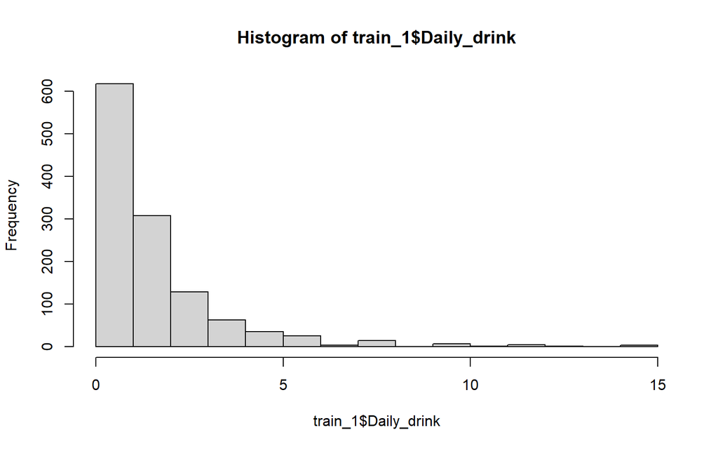

```r
hist(train_1$Daily_drink)
```

```r
mosaic::favstats(~Daily_drink,data=train_1)
```

```
 min Q1 median Q3 max     mean      sd    n missing
   0  1      1  2  15 1.862438 2.03798 1214       0
```

Here is the distribution of outcome. We can find that 75% samples are equal or less than 2 and there are only fewer samples when k>6. Also, the zero point has too many observations. Therefore, a Zero-Inflation model may fit data well.

## 5.3 fit model

We decide to fit four models. Using Poisson distribution and negative binomial distribution, Zero-Inflation(fit zero counting as observed value) model and original model respectively.

```r
ZIP<-zeroinfl(Daily_drink~Age+Race+SBP+HDL+LDL,data=train_1)
Poisson<-glm(Daily_drink~Age+Race+SBP+HDL+LDL,data=train_1,
               family = "poisson")
ZINB<-zeroinfl(Daily_drink~Age+Race+SBP+HDL+LDL,
                   data=train_1,dist ="negbin" )
Bino<-MASS::glm.nb(Daily_drink~Age+Race+SBP+HDL+LDL,data=train_1)
```

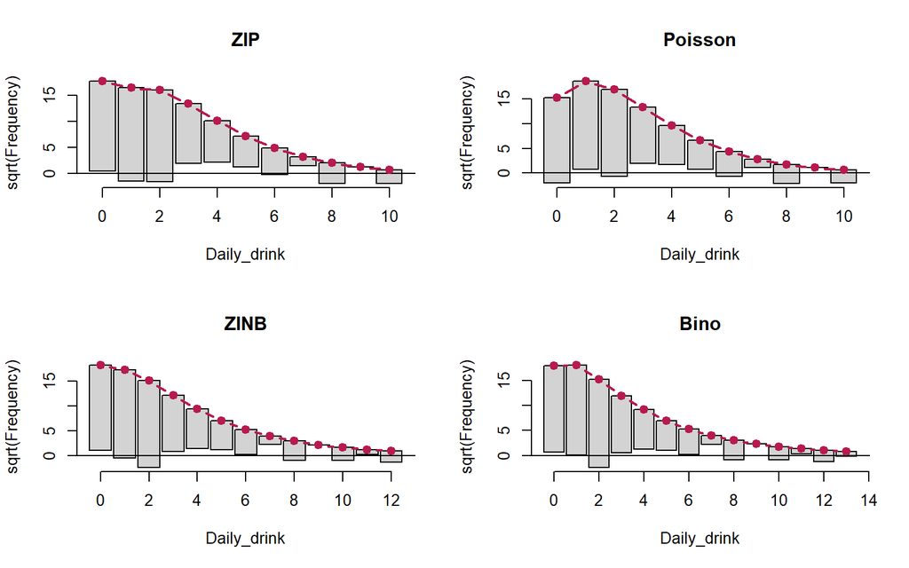

```r
par(mfrow = c(2,2))
rootogram(ZIP)
rootogram(Poisson)
rootogram(ZINB)
rootogram(Bino)
```

Looking at these rootogram plots, the gap between histogram and x-axis is the difference between expected count and observed count(the residuals).

All models don’t fit well when the counting k is larger than 10. There are too fewer observation and expected counting.

```r
AIC(ZIP,Poisson,ZINB,Bino)
```

```
        df      AIC
ZIP     18 4360.012
Poisson  9 4442.881
ZINB    19 4235.068
Bino    10 4242.556
```

Comparing AIC for different models, the two negative Binomial models have lower AIC than two Poisson models. Two zero-Inflation models have lower AIC than two original models.

Therefore, we may think the ZINB model fits best.

## 5.4 Goodness of fit

Now we want to test whether the best model is negative Binomial ZI model.

We can use training data to calculate R-square, square root of mean error and maximum error of all models and compared with each other.

Here is those statistics for negative binomial ZI model:

```r
ZINB_aug <- train_1 %>%
    mutate(".fitted" = predict(ZINB, type = "response"),
           ".resid" = resid(ZINB, type = "response"))
mets<-metric_set(rsq,rmse,mae)
ZINB_sum<-mets(ZINB_aug,truth=Daily_drink,estimate=.fitted)%>%
  mutate(model="ZINB")%>%relocate(model)
ZINB_sum%>%kable()
```

| model | .metric | .estimator | .estimate |
| --- | --- | --- | --- |
| ZINB | rsq | standard | 0.1331887 |
| ZINB | rmse | standard | 1.8966815 |
| ZINB | mae | standard | 1.2667308 |

```r
Bino_aug <- train_1 %>%
    mutate(".fitted" = predict(Bino, type = "response"),
           ".resid" = resid(Bino, type = "response"))
Bino_sum<-mets(Bino_aug,truth=Daily_drink,estimate=.fitted)%>%
  mutate(model="Bino")%>%relocate(model)

Poisson_aug <- train_1 %>%
    mutate(".fitted" = predict(Poisson, type = "response"),
           ".resid" = resid(Poisson, type = "response"))
Poisson_sum<-mets(Poisson_aug,truth=Daily_drink,estimate=.fitted)%>%
  mutate(model="Poisson")%>%relocate(model)

ZIP_aug <- train_1 %>%
    mutate(".fitted" = predict(ZIP, type = "response"),
           ".resid" = resid(ZIP, type = "response"))
ZIP_sum<-mets(ZIP_aug,truth=Daily_drink,estimate=.fitted)%>%
  mutate(model="Poisson-ZI")%>%relocate(model)
```

Here is the summary of four models.

```r
bind_rows(ZINB_sum,Bino_sum,
  Poisson_sum,ZIP_sum)%>%
  pivot_wider(names_from = model,
              values_from = .estimate)%>%
  kable(digits = 3)
```

| .metric | .estimator | ZINB | Bino | Poisson | Poisson-ZI |
| --- | --- | --- | --- | --- | --- |
| rsq | standard | 0.133 | 0.123 | 0.125 | 0.129 |
| rmse | standard | 1.897 | 1.909 | 1.906 | 1.902 |
| mae | standard | 1.267 | 1.281 | 1.278 | 1.269 |

ZINB model still has highest R-squared and least square root mean standard error and maximum error. This model has best performance fitting training data.

## 5.5 test data

We can also use test data to calculate those statistics and find whether there is overfitting.

```r
test_ZINB<-predict(ZINB,newdata=test_1,type="response")
ZINB_sum2<-mets(test_1,truth = Daily_drink,estimate=test_ZINB)%>%
  mutate(model="ZINB")%>%relocate(model)
ZINB_sum2%>%kable(digits = 3)
```

| model | .metric | .estimator | .estimate |
| --- | --- | --- | --- |
| ZINB | rsq | standard | 0.129 |
| ZINB | rmse | standard | 2.062 |
| ZINB | mae | standard | 1.359 |

In this case, the R-square becomes lower and error terms become bigger compared with result from training data.

Let’s look at other models’ results.

```r
test_Bino<-predict(Bino,newdata=test_1,type="response")
Bino_sum2<-mets(test_1,truth = Daily_drink,estimate=test_Bino)%>%
  mutate(model="Bino")%>%relocate(model)

test_ZIP<-predict(ZIP,newdata=test_1,type="response")
ZIP_sum2<-mets(test_1,truth = Daily_drink,estimate=test_ZIP)%>%
  mutate(model="ZIP")%>%relocate(model)

test_Poisson<-predict(Poisson,newdata=test_1,type="response")
Poisson_sum2<-mets(test_1,truth = Daily_drink,estimate=test_Poisson)%>%
 mutate(model="Poisson")%>%relocate(model)
```

```r
bind_rows(ZINB_sum2,Bino_sum2,
  Poisson_sum2,ZIP_sum2)%>%
  pivot_wider(names_from = model,
              values_from = .estimate)%>%
  kable(digits = 3)
```

| .metric | .estimator | ZINB | Bino | Poisson | ZIP |
| --- | --- | --- | --- | --- | --- |
| rsq | standard | 0.129 | 0.113 | 0.117 | 0.128 |
| rmse | standard | 2.062 | 2.082 | 2.077 | 2.064 |
| mae | standard | 1.359 | 1.370 | 1.367 | 1.359 |

Still, the ZINB model fit test data best among these models.

However, we can find even ZINB model is the best one among these four candidates, it contains R-square of 0.13, which means the model can only explain 13% of variance of the outcome. It’s a very low level and the result will be poor prediction.

## 5.6 Conclusion

We think negative binomial Zero-inflation model is the model we can use to explain the some features of the data.

Here is its coefficients and rootogram plot:

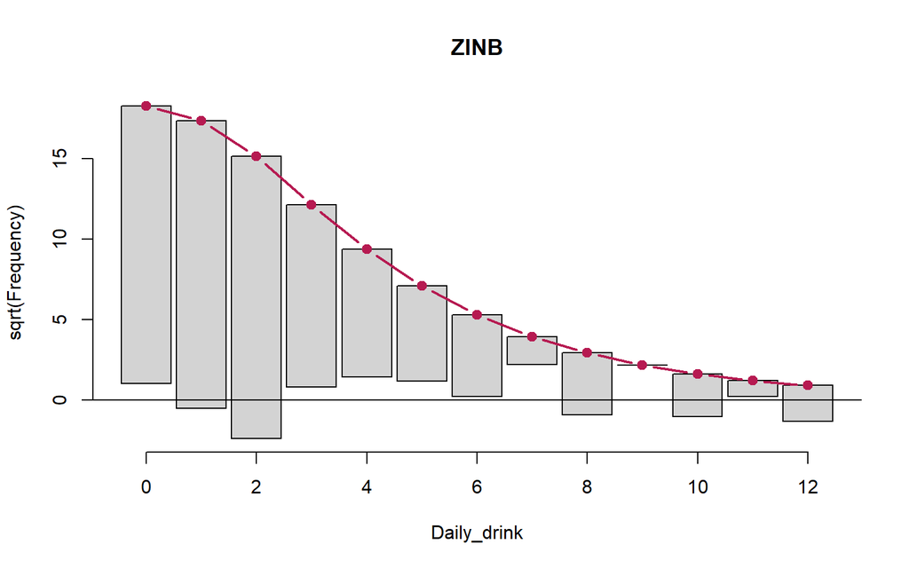

```r
rootogram(ZINB)
```

```r
summary(ZINB)
```

```
Call:
zeroinfl(formula = Daily_drink ~ Age + Race + SBP + HDL + LDL, data = train_1,
    dist = "negbin")

Pearson residuals:
    Min      1Q  Median      3Q     Max
-1.4088 -0.7344 -0.1742  0.4034  8.9906

Count model coefficients (negbin with log link):
                         Estimate Std. Error z value Pr(>|z|)
(Intercept)             1.2460310  0.2523303   4.938 7.89e-07 ***
Age                    -0.0178970  0.0020134  -8.889  < 2e-16 ***
RaceOther_Hispanic     -0.3919401  0.1172529  -3.343 0.000830 ***
RaceNon-Hispanic_White -0.2855100  0.0814552  -3.505 0.000456 ***
RaceNon-Hispanic_Black -0.4057310  0.0869340  -4.667 3.05e-06 ***
RaceNon-Hispanic_Asian -0.6791090  0.1089349  -6.234 4.54e-10 ***
SBP                     0.0051928  0.0018574   2.796 0.005178 **
HDL                    -0.0011850  0.0018950  -0.625 0.531762
LDL                     0.0002533  0.0010696   0.237 0.812773
Log(theta)              1.2729851  0.1326627   9.596  < 2e-16 ***

Zero-inflation model coefficients (binomial with logit link):
                         Estimate Std. Error z value Pr(>|z|)
(Intercept)            -8.4923394  3.2752337  -2.593  0.00952 **
Age                     0.1193944  0.0502172   2.378  0.01743 *
RaceOther_Hispanic     -0.1579795  1.6073468  -0.098  0.92171
RaceNon-Hispanic_White  0.4926004  0.9266866   0.532  0.59502
RaceNon-Hispanic_Black  0.5983386  1.1650659   0.514  0.60756
RaceNon-Hispanic_Asian -0.6268240  1.7142697  -0.366  0.71463
SBP                     0.0164115  0.0143352   1.145  0.25227
HDL                    -0.0923303  0.0355460  -2.597  0.00939 **
LDL                     0.0003743  0.0177484   0.021  0.98317
---
Signif. codes:  0 '***' 0.001 '**' 0.01 '*' 0.05 '.' 0.1 ' ' 1

Theta = 3.5715
Number of iterations in BFGS optimization: 37
Log-likelihood: -2099 on 19 Df
```

We can find that this model contains two part: A logistic model to indicate whether the outcome equals to zero and a counting regression model to estimate outcome that larger than zero.

Compared with those coefficients, we can find the effect:

Because we can calculate exp(-0.0178970*20)=0.70.

[output not shown]

## 5.7 Limitation

Even if we can have conclusions above from ZINB model, there is still one issue we cannot ignore: the R-square is only 0.13. In another word, it’s a poor prediction and all analysis and conclusions may be wrong.

One way to improve the model is changing the list of predictors.

From the result of ZINB model, we can find `HDL` and `LDL` have very small effect on detecting drinking situation. They should be considered whether to remove from this model at first.

Also, we can think about other predictions that can be added in our models.

# 6 Qustion 2

In question 2, we want to use education levels, smoking status, vigorous work day, nonfood money spend, alcohol drinking and the self-reported greatest weight to predict the class of the annual family income factor, `AFI_Factor`. This outcome variable is defined by the `Income` variable and it has three levels: 1: 1_Low_income_level with `Income` <= 5; 2:“2_Middle_income_level” with `Income` is 6, 7, 8 or 9; 3. 3_High_income_level with `Income` being 10 and above. The distribution of the `AFI_Factor` can be viewed below in the bar chart.

```r
train_1 %>% count(AFI_factor)
```

```
# A tibble: 3 x 2
  AFI_factor                n
  <ord>                 <int>
1 1_Low_income_level      336
2 2_Middle_income_level   459
3 3_High_income_level     419
```

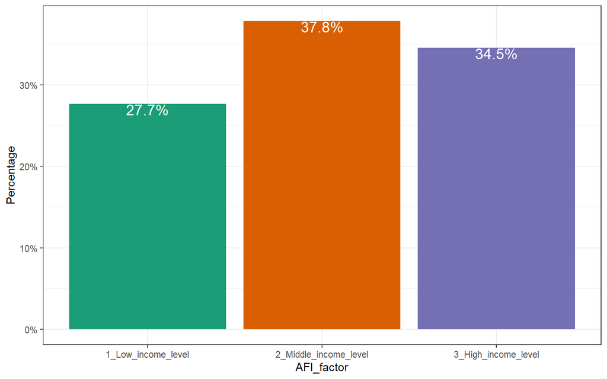

```r
ggplot(train_1, aes(x = AFI_factor, fill = AFI_factor)) +
    geom_bar(aes(y = (..count..)/sum(..count..))) +
    geom_text(aes(y = (..count..)/sum(..count..),
                  label = scales::percent((..count..) /
                                        sum(..count..))),
              stat = "count", vjust = 1,
              color = "white", size = 5) +
    scale_y_continuous(labels = scales::percent) +
    scale_fill_brewer(palette = "Dark2") +
    guides(fill = "none") +
    labs(y = "Percentage")
```

In the variable AFI_factor, we have almost uniformly distributed counts in the three classes: 336 observations in low class, 459 observations in middle(medium) class, and 419 in high class.

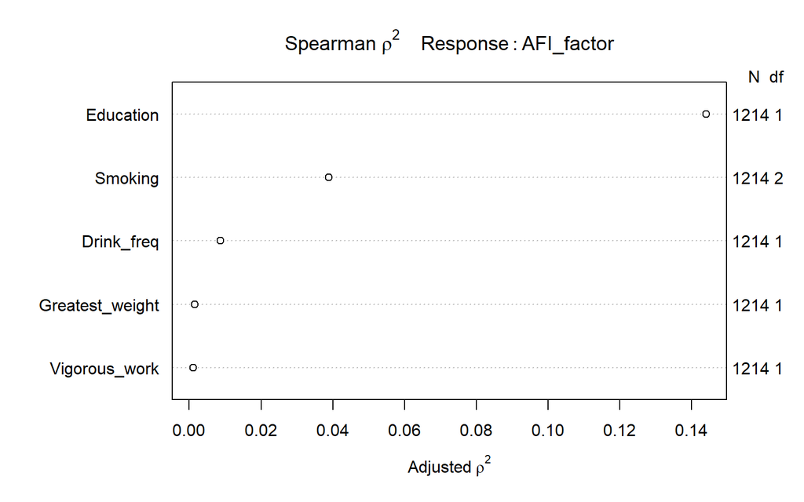

```r
plot(spearman2(AFI_factor ~ Smoking + Education + Vigorous_work + Greatest_weight + Drink_freq, data=train_1))
```

## 6.1 Exploring the variables

First we want to test the relationship between the class of annual income and the other variables. We used violin charts to explore the numerical ones and cross-tab tables with column-wise marginal proportions to explore the possible effects of each category of the categorical variables.

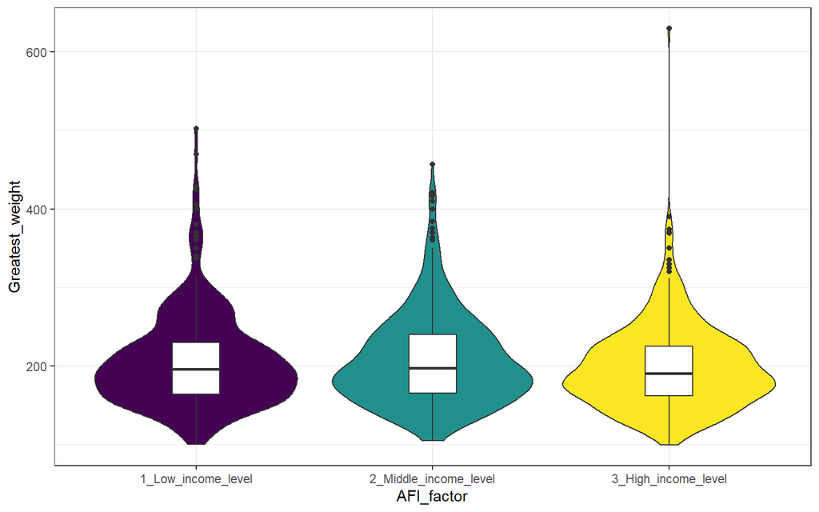

```r
ggplot(train_1, aes(x = AFI_factor, y = Greatest_weight )) +
    geom_violin(aes(fill = AFI_factor), trim = TRUE) +
    geom_boxplot(width = 0.2) +
    guides(fill = "none", color = "none") +
    theme_bw()
```

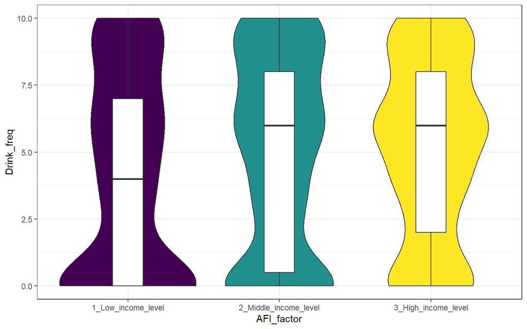

```r
ggplot(train_1, aes(x = AFI_factor, y = Drink_freq )) +
    geom_violin(aes(fill = AFI_factor), trim = TRUE) +
    geom_boxplot(width = 0.2) +
    guides(fill = "none", color = "none") +
    theme_bw()
```

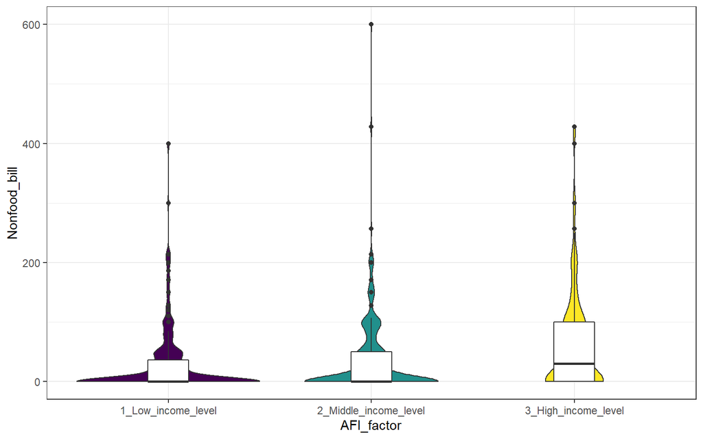

```r
ggplot(train_1, aes(x = AFI_factor, y = Nonfood_bill )) +
    geom_violin(aes(fill = AFI_factor), trim = TRUE) +
    geom_boxplot(width = 0.2) +
    guides(fill = "none", color = "none") +
    theme_bw()
```

```r
table_ed <- table(train_1$AFI_factor, train_1$Education)
prop.table(table_ed,2)
```

```
                                1         2         3         4         5
  1_Low_income_level    0.3918919 0.4697987 0.3612903 0.2335025 0.1149826
  2_Middle_income_level 0.4729730 0.4093960 0.4258065 0.4137056 0.2369338
  3_High_income_level   0.1351351 0.1208054 0.2129032 0.3527919 0.6480836
```

```r
table_smoke <- table(train_1$AFI_factor, train_1$Smoking)
prop.table(table_smoke,2)
```

```
                        Smoke_Every_day Some_Days Never_Smoke
  1_Low_income_level          0.4245810 0.2245902   0.2894118
  2_Middle_income_level       0.4189944 0.3590164   0.3882353
  3_High_income_level         0.1564246 0.4163934   0.3223529
```

```r
table_wk <- table(train_1$AFI_factor, train_1$Vigorous_work)
prop.table(table_wk,2)
```

```
                                1         2         3         4         5
  1_Low_income_level    0.1538462 0.3170732 0.2840909 0.2799401 0.2734375
  2_Middle_income_level 0.3846154 0.4390244 0.3522727 0.3517964 0.4921875
  3_High_income_level   0.4615385 0.2439024 0.3636364 0.3682635 0.2343750

                                6         7
  1_Low_income_level    0.1666667 0.3684211
  2_Middle_income_level 0.5833333 0.3684211
  3_High_income_level   0.2500000 0.2631579
```

For categorical variables, we did see a higher education can lead to a better income class, however, for the other categorical variables, it was not easy to tell the how well they can help predicting the target without further statistical testings or modelings.

In the next, we will start with a toy model, and then a full kitchen sink model, and then finally select a best model.

## 6.2 A toy model

I built a model using the proportional odds logistic regression to predict the target with the variable for self reported greatest weight.

```r
m1 <- polr(AFI_factor ~ Greatest_weight , data = train_1, Hess = TRUE)
summary(m1)
```

```
Call:
polr(formula = AFI_factor ~ Greatest_weight, data = train_1,
    Hess = TRUE)

Coefficients:
                    Value Std. Error t value
Greatest_weight -0.001818  0.0009162  -1.984

Intercepts:
                                          Value   Std. Error t value
1_Low_income_level|2_Middle_income_level  -1.3352  0.1998    -6.6844
2_Middle_income_level|3_High_income_level  0.2700  0.1958     1.3792

Residual Deviance: 2643.585
AIC: 2649.585
```

```r
confint(m1,level = 0.90)
```

```
          5 %          95 %
-0.0033214469 -0.0003191103
```

```r
temp.dat <- data.frame(name = c("Harry", "Sally","Jerry"),
                       Greatest_weight  = c(1,7,10))
predict(m1, temp.dat, type = "p")
```

```
  1_Low_income_level 2_Middle_income_level 3_High_income_level
1          0.2085932             0.3589460           0.4324608
2          0.2103991             0.3598146           0.4297863
3          0.2113064             0.3602430           0.4284506
```

## 6.3 Model 2 - A Kitchen Sink Model

```r
m2 <- polr(AFI_factor ~ Smoking + Education + Vigorous_work + Nonfood_bill+ Drink_freq + Greatest_weight, data = train_1)
summary(m2)
```

```
Call:
polr(formula = AFI_factor ~ Smoking + Education + Vigorous_work +
    Nonfood_bill + Drink_freq + Greatest_weight, data = train_1)

Coefficients:
                       Value Std. Error t value
SmokingSome_Days    0.789260  0.1645280   4.797
SmokingNever_Smoke  0.622975  0.1728786   3.604
Education           0.573696  0.0511873  11.208
Vigorous_work      -0.098591  0.0523683  -1.883
Nonfood_bill        0.005181  0.0008893   5.826
Drink_freq          0.044592  0.0157851   2.825
Greatest_weight    -0.001007  0.0009546  -1.055

Intercepts:
                                          Value   Std. Error t value
1_Low_income_level|2_Middle_income_level   1.3430  0.3683     3.6463
2_Middle_income_level|3_High_income_level  3.2211  0.3796     8.4864

Residual Deviance: 2402.673
AIC: 2420.673
```

```r
stats::step(m2)
```

```
Start:  AIC=2420.67
AFI_factor ~ Smoking + Education + Vigorous_work + Nonfood_bill +
    Drink_freq + Greatest_weight

                  Df    AIC
- Greatest_weight  1 2419.8
<none>               2420.7
- Vigorous_work    1 2422.2
- Drink_freq       1 2426.7
- Smoking          2 2440.0
- Nonfood_bill     1 2457.0
- Education        1 2552.9

Step:  AIC=2419.8
AFI_factor ~ Smoking + Education + Vigorous_work + Nonfood_bill +
    Drink_freq

                Df    AIC
<none>             2419.8
- Vigorous_work  1 2421.5
- Drink_freq     1 2425.8
- Smoking        2 2439.7
- Nonfood_bill   1 2456.4
- Education      1 2552.5
```

```
Call:
polr(formula = AFI_factor ~ Smoking + Education + Vigorous_work +
    Nonfood_bill + Drink_freq, data = train_1)

Coefficients:
  SmokingSome_Days SmokingNever_Smoke          Education      Vigorous_work
       0.798372400        0.619204098        0.574580018       -0.101013455
      Nonfood_bill         Drink_freq
       0.005202028        0.044510767

Intercepts:
 1_Low_income_level|2_Middle_income_level
                                 1.547358
2_Middle_income_level|3_High_income_level
                                 3.424363

Residual Deviance: 2403.796
AIC: 2419.796
```

To obtain the appropriate Wald tests, I used lrm function to fit the model instead.

```r
d <- datadist(train_1)
options(datadist = "d")
m2_lrm <- lrm(AFI_factor ~ Smoking + Education + Vigorous_work + Nonfood_bill+ Drink_freq, data = train_1, x = T, y = T)
m2_lrm
```

```
Logistic Regression Model

 lrm(formula = AFI_factor ~ Smoking + Education + Vigorous_work +
     Nonfood_bill + Drink_freq, data = train_1, x = T, y = T)

                                Model Likelihood    Discrimination    Rank Discrim.
                                      Ratio Test           Indexes          Indexes
         Obs          1214    LR chi2     243.77    R2       0.205    C       0.708
     1_Low_income_level336    d.f.             6    g        1.021    Dxy     0.416
  2_Middle_income_level459    Pr(> chi2) <0.0001    gr       2.776    gamma   0.417
    3_High_income_level419                          gp       0.180    tau-a   0.275
         max |deriv| 3e-07                          Brier    0.183

                          Coef    S.E.   Wald Z Pr(>|Z|)
 y>=2_Middle_income_level -1.5474 0.3137  -4.93 <0.0001
 y>=3_High_income_level   -3.4244 0.3277 -10.45 <0.0001
 Smoking=Some_Days         0.7984 0.1643   4.86 <0.0001
 Smoking=Never_Smoke       0.6192 0.1728   3.58 0.0003
 Education                 0.5746 0.0512  11.23 <0.0001
 Vigorous_work            -0.1010 0.0523  -1.93 0.0536
 Nonfood_bill              0.0052 0.0009   5.85 <0.0001
 Drink_freq                0.0445 0.0158   2.82 0.0048
```

In the odds ratio plot, we can see that the odds ratio for nonfood_bill, drink_freq, and education-graduate/higher is bigger than one, which indicates a positive association. Other variables have odd ratios that are less than one, which indicates a negative association.

```r
exp(coef(m2))
```

```
  SmokingSome_Days SmokingNever_Smoke          Education      Vigorous_work
         2.2017657          1.8644660          1.7748142          0.9061134
      Nonfood_bill         Drink_freq    Greatest_weight
         1.0051948          1.0456007          0.9989934
```

```r
exp(confint(m2))
```

```
                       2.5 %   97.5 %
SmokingSome_Days   1.5966742 3.044289
SmokingNever_Smoke 1.3300542 2.620285
Education          1.6066154 1.963766
Vigorous_work      0.8174755 1.003914
Nonfood_bill       1.0034830 1.006992
Drink_freq         1.0137831 1.078516
Greatest_weight    0.9971284 1.000854
```

```r
summary(m2_lrm)
```

```
             Effects              Response : AFI_factor

 Factor                              Low High Diff. Effect   S.E.
 Education                           3    4    1     0.57458 0.051183
  Odds Ratio                         3    4    1     1.77640       NA
 Vigorous_work                       3    4    1    -0.10101 0.052328
  Odds Ratio                         3    4    1     0.90392       NA
 Nonfood_bill                        0   50   50     0.26010 0.044444
  Odds Ratio                         0   50   50     1.29710       NA
 Drink_freq                          1    8    7     0.31158 0.110480
  Odds Ratio                         1    8    7     1.36560       NA
 Smoking - Smoke_Every_day:Some_Days 2    1   NA    -0.79837 0.164330
  Odds Ratio                         2    1   NA     0.45006       NA
 Smoking - Never_Smoke:Some_Days     2    3   NA    -0.17917 0.126010
  Odds Ratio                         2    3   NA     0.83597       NA
 Lower 0.95 Upper 0.95
  0.474260   0.6749000
  1.606800   1.9638000
 -0.203570   0.0015484
  0.815810   1.0015000
  0.172990   0.3472100
  1.188900   1.4151000
  0.095041   0.5281100
  1.099700   1.6957000
 -1.120400  -0.4763000
  0.326130   0.6210800
 -0.426150   0.0678130
  0.653020   1.0702000
```

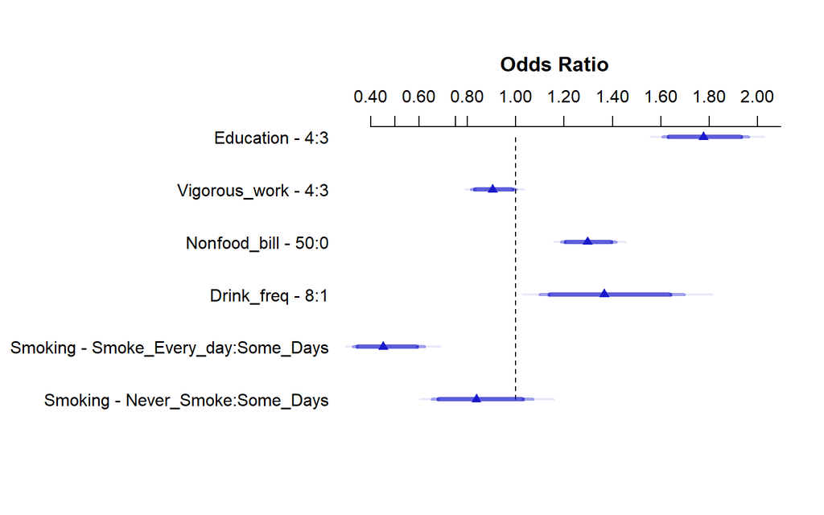

```r
plot(summary(m2_lrm))
```

## 6.4 Test model2

From the result of validation, we might expect a Nagelkerke R^2 of 0.1961 and a C statistic value = 0.5 + (0.41/2) = 0.705> 0.5. The model is at correctly classifying outcomes.

```r
set.seed(432);
validate(m2_lrm)
```

```
          index.orig training    test optimism index.corrected  n
Dxy           0.4159   0.4199  0.4116   0.0084          0.4076 40
R2            0.2051   0.2097  0.2008   0.0090          0.1961 40
Intercept     0.0000   0.0000  0.0174  -0.0174          0.0174 40
Slope         1.0000   1.0000  0.9766   0.0234          0.9766 40
Emax          0.0000   0.0000  0.0082   0.0082          0.0082 40
D             0.2000   0.2054  0.1953   0.0100          0.1899 40
U            -0.0016  -0.0016 -0.8892   0.8876         -0.8892 40
Q             0.2016   0.2070  1.0846  -0.8775          1.0792 40
B             0.1835   0.1821  0.1843  -0.0022          0.1856 40
g             1.0209   1.0363  1.0061   0.0301          0.9907 40
gp            0.1804   0.1820  0.1786   0.0034          0.1770 40
```

Then we want to test Proportional Odds Assumption.

```r
m2_multi <- multinom(Annual_family_income ~ Smoking + Education + Vigorous_work + Nonfood_bill + Drink_freq+ Greatest_weight, data = train_1)
```

The result of the test is significant, suggesting that we have a problem somewhere with the proportional odds assumption. Then I built some plot of score residuals. In the plots, as the annual family income change, the value of variables doesn’t change much, which means they are stable.

```r
LL_2 <- logLik(m2)
LL_2m <- logLik(m2_multi)
(G <- -2 * (LL_2[1] - LL_2m[1]))
```

```
[1] 24.26867
```

```r
pchisq(G, 9, lower.tail = FALSE)
```

```
[1] 0.003896165
```

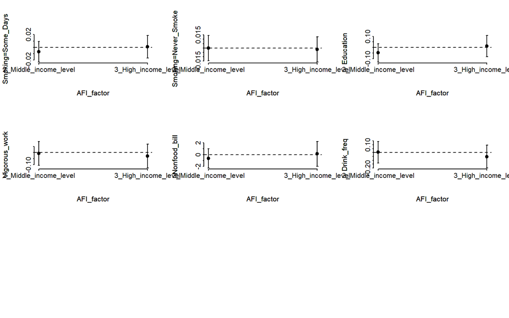

```r
par(mfrow = c(3,3))
resid(m2_lrm, 'score.binary', pl=TRUE)
par(mfrow= c(1,1))
```

```r
m3 <- polr(AFI_factor ~ Smoking + rcs(Education,5) + Vigorous_work + Nonfood_bill+ rcs(Drink_freq,3) + Greatest_weight
  +Drink_freq %ia% Vigorous_work+Smoking %ia% Drink_freq+Vigorous_work %ia% Smoking , data = train_1)

summary(m3)
```

```
Call:
polr(formula = AFI_factor ~ Smoking + rcs(Education, 5) + Vigorous_work +
    Nonfood_bill + rcs(Drink_freq, 3) + Greatest_weight + Drink_freq %ia%
    Vigorous_work + Smoking %ia% Drink_freq + Vigorous_work %ia%
    Smoking, data = train_1)

Coefficients:
                                                                   Value
SmokingSome_Days                                               0.8960713
SmokingNever_Smoke                                            -0.1600376
rcs(Education, 5)Education                                     0.0854146
rcs(Education, 5)Education'                                    0.5401635
Vigorous_work                                                 -0.2018272
Nonfood_bill                                                   0.0049340
rcs(Drink_freq, 3)Drink_freq                                   0.1386591
rcs(Drink_freq, 3)Drink_freq'                                 -0.1593735
Greatest_weight                                               -0.0005334
Drink_freq %ia% Vigorous_work                                  0.0100254
Smoking %ia% Drink_freqSmoking=Some_Days * Drink_freq         -0.0198352
Smoking %ia% Drink_freqSmoking=Never_Smoke * Drink_freq       -0.0269471
Vigorous_work %ia% SmokingVigorous_work * Smoking=Some_Days   -0.0234618
Vigorous_work %ia% SmokingVigorous_work * Smoking=Never_Smoke  0.2232821
                                                              Std. Error
SmokingSome_Days                                               0.6522236
SmokingNever_Smoke                                             0.6734571
rcs(Education, 5)Education                                     0.1240540
rcs(Education, 5)Education'                                    0.1306486
Vigorous_work                                                  0.1476445
Nonfood_bill                                                   0.0008936
rcs(Drink_freq, 3)Drink_freq                                   0.0835145
rcs(Drink_freq, 3)Drink_freq'                                  0.0579046
Greatest_weight                                                0.0009700
Drink_freq %ia% Vigorous_work                                  0.0152226
Smoking %ia% Drink_freqSmoking=Some_Days * Drink_freq          0.0466290
Smoking %ia% Drink_freqSmoking=Never_Smoke * Drink_freq        0.0489072
Vigorous_work %ia% SmokingVigorous_work * Smoking=Some_Days    0.1449344
Vigorous_work %ia% SmokingVigorous_work * Smoking=Never_Smoke  0.1546427
                                                              t value
SmokingSome_Days                                               1.3739
SmokingNever_Smoke                                            -0.2376
rcs(Education, 5)Education                                     0.6885
rcs(Education, 5)Education'                                    4.1345
Vigorous_work                                                 -1.3670
Nonfood_bill                                                   5.5214
rcs(Drink_freq, 3)Drink_freq                                   1.6603
rcs(Drink_freq, 3)Drink_freq'                                 -2.7523
Greatest_weight                                               -0.5499
Drink_freq %ia% Vigorous_work                                  0.6586
Smoking %ia% Drink_freqSmoking=Some_Days * Drink_freq         -0.4254
Smoking %ia% Drink_freqSmoking=Never_Smoke * Drink_freq       -0.5510
Vigorous_work %ia% SmokingVigorous_work * Smoking=Some_Days   -0.1619
Vigorous_work %ia% SmokingVigorous_work * Smoking=Never_Smoke  1.4439

Intercepts:
                                          Value   Std. Error t value
1_Low_income_level|2_Middle_income_level   0.1238  0.7283     0.1699
2_Middle_income_level|3_High_income_level  2.0366  0.7311     2.7858

Residual Deviance: 2372.519
AIC: 2404.519
```

```r
stats::step(m3)
```

```
Start:  AIC=2404.52
AFI_factor ~ Smoking + rcs(Education, 5) + Vigorous_work + Nonfood_bill +
    rcs(Drink_freq, 3) + Greatest_weight + Drink_freq %ia% Vigorous_work +
    Smoking %ia% Drink_freq + Vigorous_work %ia% Smoking

                                Df    AIC
- Smoking %ia% Drink_freq        2 2400.8
- Greatest_weight                1 2402.8
- Drink_freq %ia% Vigorous_work  1 2402.9
- Vigorous_work                  1 2404.4
<none>                             2404.5
- Vigorous_work %ia% Smoking     2 2404.9
- Smoking                        2 2405.6
- rcs(Drink_freq, 3)             2 2408.3
- Nonfood_bill                   1 2436.5
- rcs(Education, 5)              2 2542.5

Step:  AIC=2400.82
AFI_factor ~ Smoking + rcs(Education, 5) + Vigorous_work + Nonfood_bill +
    rcs(Drink_freq, 3) + Greatest_weight + Drink_freq %ia% Vigorous_work +
    Vigorous_work %ia% Smoking

                                Df    AIC
- Greatest_weight                1 2399.1
- Drink_freq %ia% Vigorous_work  1 2399.4
<none>                             2400.8
- Vigorous_work                  1 2400.9
- Vigorous_work %ia% Smoking     2 2401.3
- Smoking                        2 2402.3
- rcs(Drink_freq, 3)             2 2404.4
- Nonfood_bill                   1 2432.8
- rcs(Education, 5)              2 2538.7

Step:  AIC=2399.11
AFI_factor ~ Smoking + rcs(Education, 5) + Vigorous_work + Nonfood_bill +
    rcs(Drink_freq, 3) + Drink_freq %ia% Vigorous_work + Vigorous_work %ia%
    Smoking

                                Df    AIC
- Drink_freq %ia% Vigorous_work  1 2397.7
```

[output cut: 17 more lines]

```
- rcs(Drink_freq, 3)          2 2409.7
- Nonfood_bill                1 2430.5
- rcs(Education, 5)           2 2536.3

Step:  AIC=2397.19
AFI_factor ~ Smoking + rcs(Education, 5) + Nonfood_bill + rcs(Drink_freq,
    3) + Vigorous_work %ia% Smoking

                             Df    AIC
<none>                          2397.2
- Vigorous_work %ia% Smoking  2 2398.7
- rcs(Drink_freq, 3)          2 2409.2
- Smoking                     2 2409.6
- Nonfood_bill                1 2430.0
- rcs(Education, 5)           2 2536.0
```

```
Call:
polr(formula = AFI_factor ~ Smoking + rcs(Education, 5) + Nonfood_bill +
    rcs(Drink_freq, 3) + Vigorous_work %ia% Smoking, data = train_1)

Coefficients:
                                             SmokingSome_Days
                                                  1.413175414
                                           SmokingNever_Smoke
                                                  0.383736482
                                   rcs(Education, 5)Education
                                                  0.076754881
                                  rcs(Education, 5)Education'
                                                  0.548589236
                                                 Nonfood_bill
                                                  0.004983743
                                 rcs(Drink_freq, 3)Drink_freq
                                                  0.151915354
                                rcs(Drink_freq, 3)Drink_freq'
                                                 -0.151058129
  Vigorous_work %ia% SmokingVigorous_work * Smoking=Some_Days
                                                 -0.170771841
Vigorous_work %ia% SmokingVigorous_work * Smoking=Never_Smoke
                                                  0.059216176

Intercepts:
 1_Low_income_level|2_Middle_income_level
                                 0.930123
2_Middle_income_level|3_High_income_level
                                 2.840126

Residual Deviance: 2375.189
AIC: 2397.189
```

```r
m3_lrm <- lrm(AFI_factor ~ Smoking + rcs(Education, 5)  +
                Nonfood_bill+rcs(Drink_freq,3)+Smoking %ia% Drink_freq,
              data = train_1, x = T, y = T)

m3_lrm
```

```
Logistic Regression Model

 lrm(formula = AFI_factor ~ Smoking + rcs(Education, 5) + Nonfood_bill +
     rcs(Drink_freq, 3) + Smoking %ia% Drink_freq, data = train_1,
     x = T, y = T)

                                Model Likelihood    Discrimination    Rank Discrim.
                                      Ratio Test           Indexes          Indexes
         Obs          1214    LR chi2     267.33    R2       0.223    C       0.713
     1_Low_income_level336    d.f.             9    g        1.089    Dxy     0.425
  2_Middle_income_level459    Pr(> chi2) <0.0001    gr       2.972    gamma   0.427
    3_High_income_level419                          gp       0.183    tau-a   0.281
         max |deriv| 6e-07                          Brier    0.181

                                  Coef    S.E.   Wald Z Pr(>|Z|)
 y>=2_Middle_income_level         -0.9910 0.3901 -2.54  0.0111
 y>=3_High_income_level           -2.8949 0.3991 -7.25  <0.0001
 Smoking=Some_Days                 0.8564 0.2867  2.99  0.0028
 Smoking=Never_Smoke               0.7321 0.2841  2.58  0.0100
 Education                         0.0548 0.1229  0.45  0.6554
 Education'                        0.5815 0.1289  4.51  <0.0001
 Nonfood_bill                      0.0049 0.0009  5.53  <0.0001
 Drink_freq                        0.1709 0.0584  2.93  0.0034
 Drink_freq'                      -0.1465 0.0575 -2.55  0.0108
 Smoking=Some_Days * Drink_freq   -0.0279 0.0464 -0.60  0.5479
 Smoking=Never_Smoke * Drink_freq -0.0303 0.0483 -0.63  0.5303
```

In the odds ratio plot, we can see that the odds ratio for education, drink_freq, and nonfood money spend is bigger than one, which indicates a positive association. Other variables shown have odd ratios that are less than one, which indicates a negative association.

```r
summary(m3_lrm)
```

```
             Effects              Response : AFI_factor

 Factor                              Low High Diff. Effect   S.E.
 Education                           3    4    1     0.78178 0.071011
  Odds Ratio                         3    4    1     2.18540       NA
 Nonfood_bill                        0   50   50     0.24494 0.044300
  Odds Ratio                         0   50   50     1.27760       NA
 Drink_freq                          1    8    7     0.33172 0.161330
  Odds Ratio                         1    8    7     1.39340       NA
 Smoking - Smoke_Every_day:Some_Days 2    1   NA    -0.71709 0.165880
  Odds Ratio                         2    1   NA     0.48817       NA
 Smoking - Never_Smoke:Some_Days     2    3   NA    -0.13653 0.126030
  Odds Ratio                         2    3   NA     0.87238       NA
 Lower 0.95 Upper 0.95
  0.642600   0.92096
  1.901400   2.51170
  0.158120   0.33177
  1.171300   1.39340
  0.015508   0.64793
  1.015600   1.91160
 -1.042200  -0.39196
  0.352670   0.67573
 -0.383550   0.11048
  0.681440   1.11680

Adjusted to: Smoking=Some_Days Drink_freq=5
```

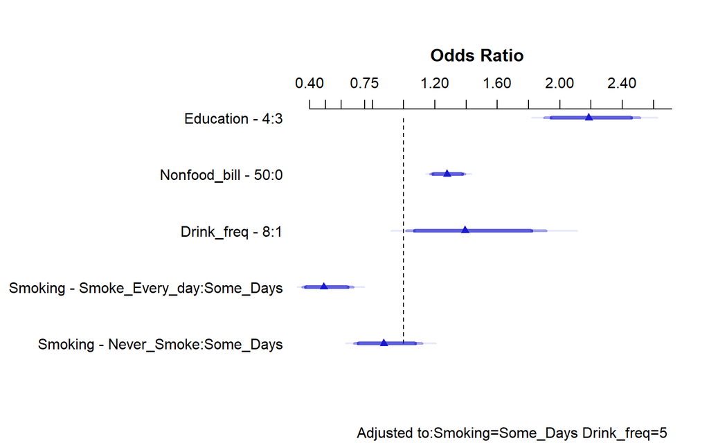

```r
plot(summary(m3_lrm))
```

```r
set.seed(432);
validate(m3_lrm)
```

```
          index.orig training    test optimism index.corrected  n
Dxy           0.4250   0.4308  0.4203   0.0105          0.4146 40
R2            0.2228   0.2287  0.2169   0.0118          0.2110 40
Intercept     0.0000   0.0000  0.0241  -0.0241          0.0241 40
Slope         1.0000   1.0000  0.9684   0.0316          0.9684 40
Emax          0.0000   0.0000  0.0112   0.0112          0.0112 40
D             0.2194   0.2264  0.2129   0.0135          0.2059 40
U            -0.0016  -0.0016 -0.8807   0.8790         -0.8807 40
Q             0.2210   0.2281  1.0936  -0.8655          1.0865 40
B             0.1807   0.1791  0.1818  -0.0027          0.1834 40
g             1.0893   1.1086  1.0689   0.0397          1.0496 40
gp            0.1834   0.1854  0.1812   0.0042          0.1792 40
```

## 6.6 Comparison

```r
anova(m3, m2)
```

```
Likelihood ratio tests of ordinal regression models

Response: AFI_factor
                                                                                                                                                                                     Model
1                                                                                                        Smoking + Education + Vigorous_work + Nonfood_bill + Drink_freq + Greatest_weight
2 Smoking + rcs(Education, 5) + Vigorous_work + Nonfood_bill + rcs(Drink_freq, 3) + Greatest_weight + Drink_freq %ia% Vigorous_work + Smoking %ia% Drink_freq + Vigorous_work %ia% Smoking
  Resid. df Resid. Dev   Test    Df LR stat.      Pr(Chi)
1      1205   2402.673
2      1198   2372.519 1 vs 2     7 30.15341 8.899973e-05
```

```r
AIC(m3_lrm, m2_lrm)
```

```
[1] 2402.235
```

```r
BIC(m3_lrm, m2_lrm)
```

```
       df      BIC
m3_lrm 11 2458.353
m2_lrm  8 2460.610
```

## 6.7 Conclusions

There are still shortcomings in our model, such as our AIC and BIC are relatively large, indicating that the results may not be so accurate. But this model can already explain the relationship between variables and annual income to a certain extent. We can achieve the purpose of increasing annual income through the model. For me, at the beginning I was hesitant to add the greatest weight to the model, but the class notes gave me the inspiration to take it out for analysis, which is the most valuable way to think about the project. In the next steps, I will choose to add a new predictor to further explore what affects annual income.

# 7 References and Acknowledgments

The source of our dataset: https://wwwn.cdc.gov/Nchs/Nhanes/continuousnhanes/default.aspx?BeginYear=2017

Discrete Mathematics and Probability Theory by Anant Sahai: https://inst.eecs.berkeley.edu/~cs70/fa14/notes/n7.pdf